# Basic Algorithms and Exponential Weighted Forecast

Yang Xi

17 Jan, 2018

# 3. Basic Algorithms

The section will introduce several basic algorithms of time-series forecast. These algorithms are usually used as benchmarks of more complicated methods.

### 3.1 Example: Monthly Sales Data of an Item

In this section, monthly sales data of item (id=10) will be used as an example. The following figures show the sample data’s time-series plots and ACF plots:

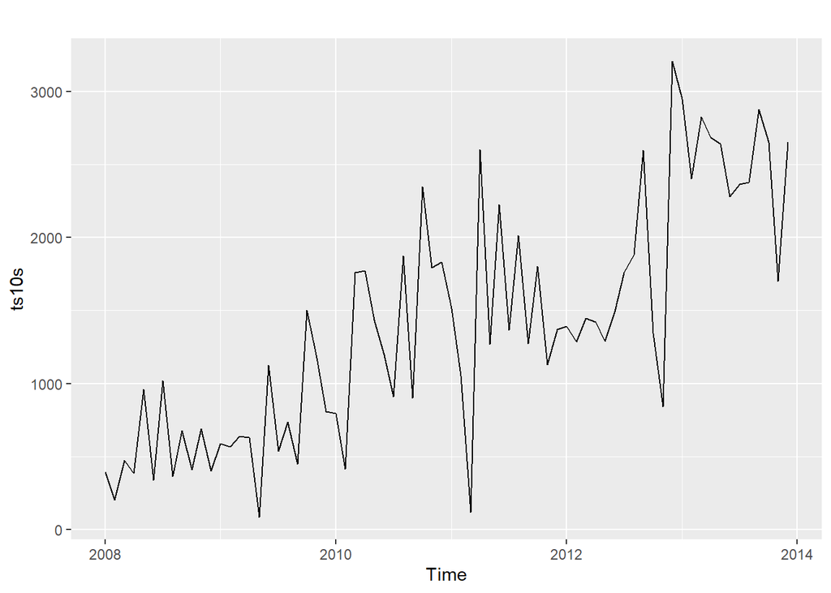

```r
library(dplyr)
library(fpp2)

load('../../data/(2017) Time Series/time_series_monthly.rdata')

dfItem10 <- dfSalesMonthly %>%
  filter(item_id == 10 & first_date >='2008-01-01' & first_date <='2013-12-31') %>%
  as.data.frame() %>%
  select(-item_id)

ts10 <- select(dfItem10, -first_date)
row.names(ts10) <-dfItem10$first_date
ts10 <- ts(ts10, start=c(2008, 1), frequency=12)
ts10s <- ts10[,'sales_qty']
autoplot(ts10s)
```

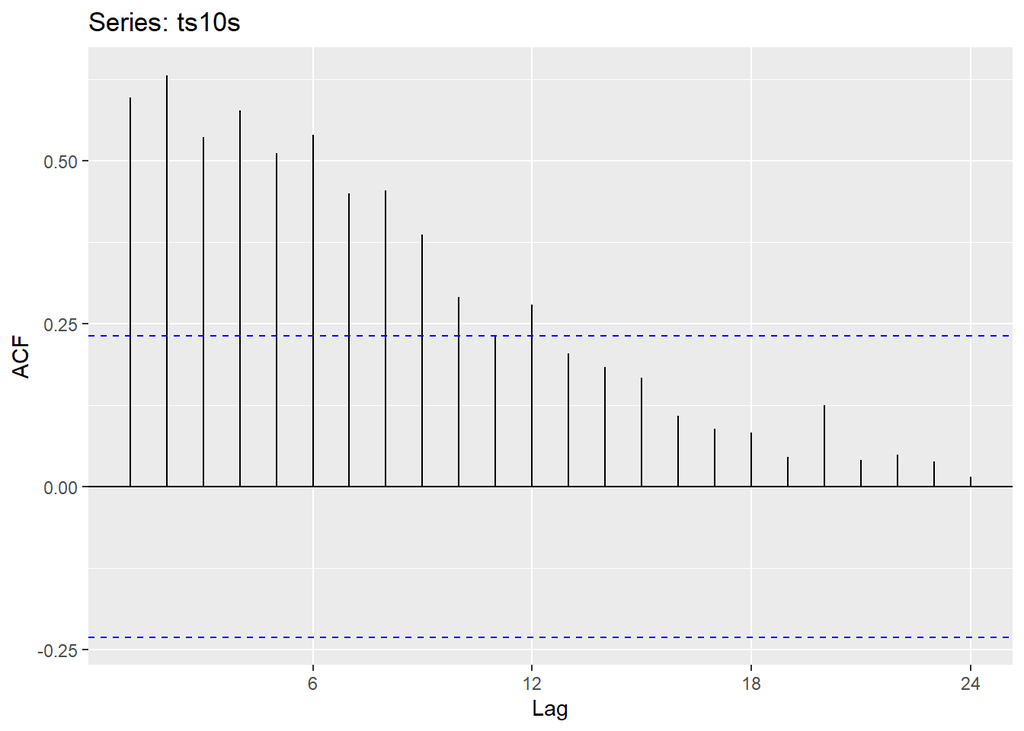

```r
ggAcf(ts10s)
```

For this sample data:

- Year 2008 – 2012 data will be used as **training set**
- Year 2013 data will be the **test set**

```r
ts10s_train <- window(ts10s, end = c(2013, 0))
ts10s_test <- window(ts10s, start = c(2013, 1))
ts10s_actual <- as.numeric(ts10s_test)

rmse_e <- function(e) {
  round(sqrt(mean(e^2, na.rm=T)), digits=2)
}


rmse <- function(pred, actual) {
  rmse_e(pred-actual)
}

mase <- function(pred, actual) {
  l <- length(pred)
  round(sum(abs(pred-actual))/sum(abs(diff(actual)))*(l-1)/l, digits=2)
}
```

### 3.2 Naïve, Mean, Seasonal Naïve

**Naïve model** uses the last value of the training data as the forecast, while Mean model uses the mean value of the training data as the forecast.  
**Seasonal Naïve model** uses the values of data in the previous defined season as forecast.  
The following figures illustrate the forecasts and residual plots of these models respectively.

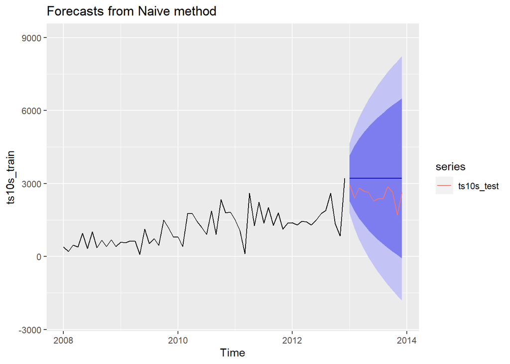

```r
# Naive
fc_naive <- naive(ts10s_train, h = 12)
autoplot(fc_naive, ylim=c(-2500, 9000)) + autolayer(ts10s_test)
```

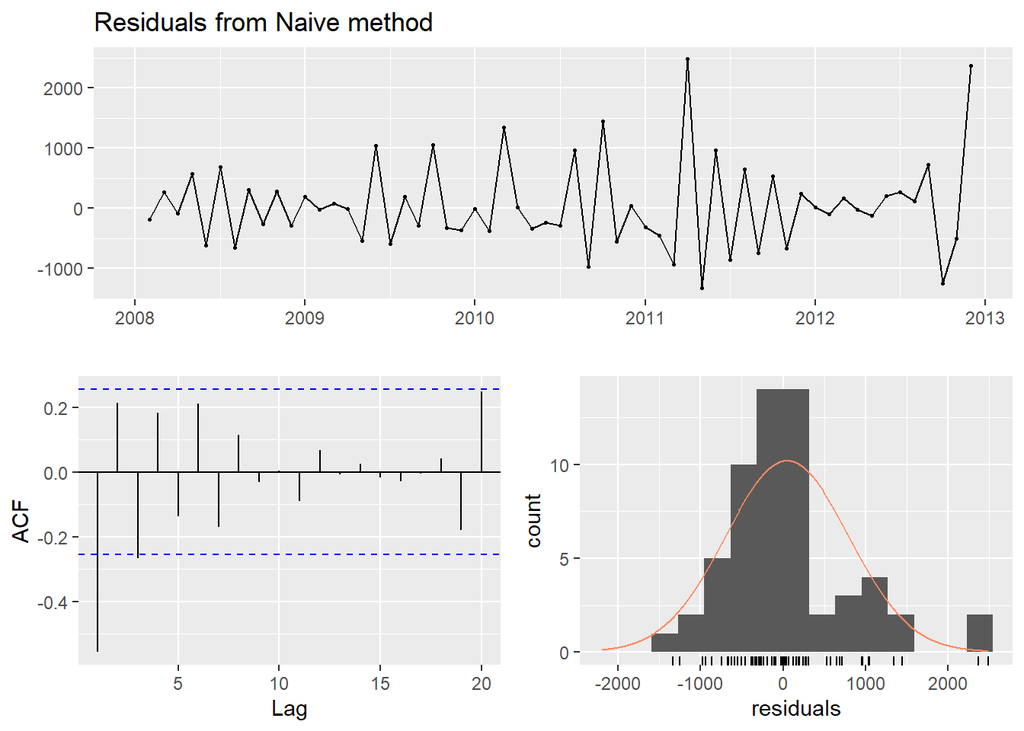

```
##
##  Ljung-Box test
##
## data:  Residuals from Naive method
## Q* = 37.101, df = 12, p-value = 0.0002152
##
## Model df: 0.   Total lags used: 12
```

```r
checkresiduals(fc_naive)
```

```r
fc_naive_rmse <- rmse(as.numeric(fc_naive$mean), ts10s_actual)
fc_naive_mase <- mase(as.numeric(fc_naive$mean), ts10s_actual)

tscv_naive <- tsCV(ts10s_train, naive, h = 12)
tscv_naive_rmse <- rmse_e(as.numeric(tscv_naive))
message("Naive model: MASE=", fc_naive_mase, " RMSE=", fc_naive_rmse, " RMSE(tsCV)=", tscv_naive_rmse)
```

```
## Naive model: MASE=1.75 RMSE=748.61 RMSE(tsCV)=713.74
```

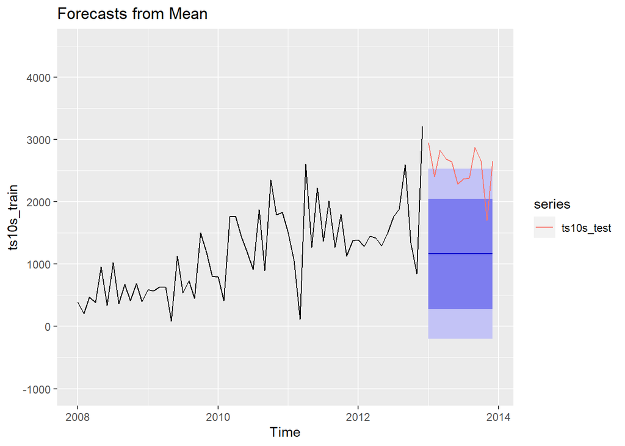

```r
# Mean
fc_mean <- meanf(ts10s_train, h = 12)
autoplot(fc_mean, ylim=c(-1000, 4500)) + autolayer(ts10s_test)
```

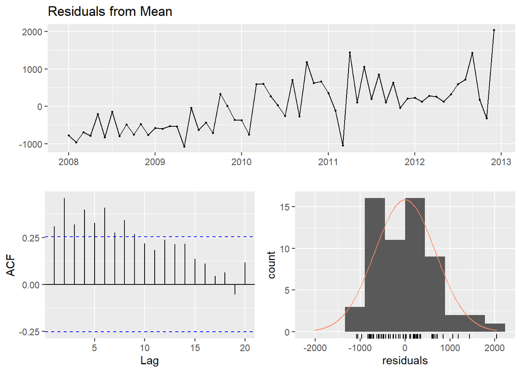

```
##
##  Ljung-Box test
##
## data:  Residuals from Mean
## Q* = 85.128, df = 11, p-value = 1.492e-13
##
## Model df: 1.   Total lags used: 12
```

```r
checkresiduals(fc_mean)
```

```r
fc_mean_rmse <- rmse(as.numeric(fc_mean$mean), ts10s_actual)
fc_mean_mase <- mase(as.numeric(fc_mean$mean), ts10s_actual)

tscv_mean <- tsCV(ts10s_train, meanf, h = 12)
tscv_mean_rmse <- rmse_e(as.numeric(tscv_mean))
message("Mean model: MASE=", fc_mean_mase, " RMSE=", fc_mean_rmse, " RMSE(tsCV)=", tscv_mean_rmse)
```

```
## Mean model: MASE=3.56 RMSE=1407.68 RMSE(tsCV)=765.03
```

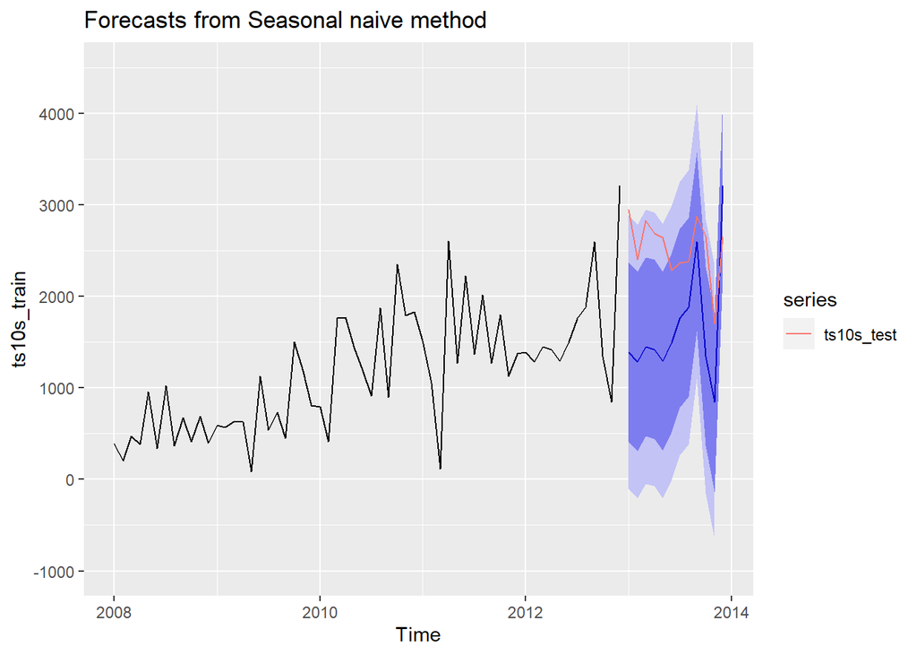

```r
# Seasonal Naive
fc_snaive <- snaive(ts10s_train, h = 12)
autoplot(fc_snaive, ylim=c(-1000, 4500)) + autolayer(ts10s_test)
```

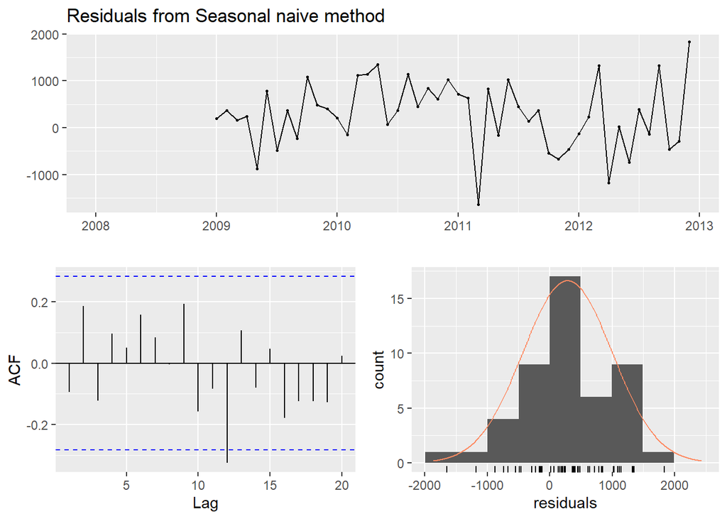

```
##
##  Ljung-Box test
##
## data:  Residuals from Seasonal naive method
## Q* = 16.937, df = 12, p-value = 0.152
##
## Model df: 0.   Total lags used: 12
```

```r
checkresiduals(fc_snaive)
```

```r
fc_snaive_rmse <- rmse(as.numeric(fc_snaive$mean), ts10s_actual)
fc_snaive_mase <- mase(as.numeric(fc_snaive$mean), ts10s_actual)

tscv_snaive <- tsCV(ts10s_train, snaive, h = 12)
tscv_snaive_rmse <- rmse_e(as.numeric(tscv_snaive))
message("snaive model: MASE=", fc_snaive_mase, " RMSE=", fc_snaive_rmse, " RMSE(tsCV)=", tscv_snaive_rmse)
```

```
## snaive model: MASE=2.5 RMSE=1043.72 RMSE(tsCV)=754.58
```

Table below summarizes the performance of these models:

```r
data.frame(Model=c("Naive","Mean","Seasonal Naive"),
           `MASE(test)`=c(fc_naive_mase,fc_mean_mase,fc_snaive_mase),
           `RMSE(test)`=c(fc_naive_rmse,fc_mean_rmse,fc_snaive_rmse),
           `RMSE(tsCV)`=c(tscv_naive_rmse,tscv_mean_rmse,tscv_snaive_rmse)) %>%
  knitr::kable()
```

| Model | MASE.test. | RMSE.test. | RMSE.tsCV. |
| --- | --- | --- | --- |
| Naive | 1.75 | 748.61 | 713.74 |
| Mean | 3.56 | 1407.68 | 765.03 |
| Seasonal Naive | 2.50 | 1043.72 | 754.58 |

# 4 Exponential Weighted Forecast

### 4.1 Simple Exponential Smoothing (SES)

Exponential smoothing is a technique to smooth time series data using the exponential window function. Whereas in the simple moving average the past observations are weighted equally, exponential functions are used to assign exponentially decreasing weights over time.

**4.1.1 Definition**
Let
$$\hat{y_{t+h|t}}=\text{point forcast of }y_{t+h}\text{ given data }y_{1},...,y_{t}$$
Forecast Equation:
$$\hat{y_{t+h|t}}= \alpha y_{t}+\alpha(1-\alpha)y_{t-1}+\alpha(1-\alpha)^{2}y_{t-2}+...\text{ where } 0\leq\alpha\leq 1$$

**4.1.2 Parameter Selection**
Let
$$\hat{y_{t+h|t}}=l_{t}$$
The forecast equation can be written as:
$$l_{t}=\alpha y_{t}+(1-\alpha)l_{t-1}$$
The parameters, $\alpha$ and $l_{0}$ can be chosen by minimizing the squared error.

**4.1.3 Example: Monthly Sales Data of an Item**  
I will use the same item with ID 10 as an example.  
Fit an SES model to the training data yields the following results:

```r
fc_ses <- ses(ts10s_train, h = 12)

summary(fc_ses)
```

```
##
## Forecast method: Simple exponential smoothing
##
## Model Information:
## Simple exponential smoothing
##
## Call:
##  ses(y = ts10s_train, h = 12)
##
##   Smoothing parameters:
##     alpha = 0.1814
##
##   Initial states:
##     l = 494.322
##
##   sigma:  548.1545
##
##      AIC     AICc      BIC
## 1006.413 1006.842 1012.696
##
## Error measures:
##                   ME     RMSE      MAE       MPE     MAPE      MASE       ACF1
## Training set 122.592 538.9412 382.3736 -28.42061 58.41173 0.6136593 -0.2381759
##
## Forecasts:
##          Point Forecast    Lo 80    Hi 80    Lo 95    Hi 95
## Jan 2013       1828.748 1126.259 2531.236 754.3846 2903.111
## Feb 2013       1828.748 1114.793 2542.703 736.8477 2920.648
## Mar 2013       1828.748 1103.507 2553.988 719.5880 2937.907
## Apr 2013       1828.748 1092.395 2565.101 702.5928 2954.903
## May 2013       1828.748 1081.447 2576.048 685.8504 2971.645
## Jun 2013       1828.748 1070.658 2586.837 669.3496 2988.146
## Jul 2013       1828.748 1060.020 2597.475 653.0805 3004.415
## Aug 2013       1828.748 1049.528 2607.968 637.0334 3020.462
## Sep 2013       1828.748 1039.174 2618.321 621.1995 3036.296
## Oct 2013       1828.748 1028.955 2628.540 605.5706 3051.925
## Nov 2013       1828.748 1018.865 2638.630 590.1389 3067.356
## Dec 2013       1828.748 1008.899 2648.597 574.8971 3082.598
```

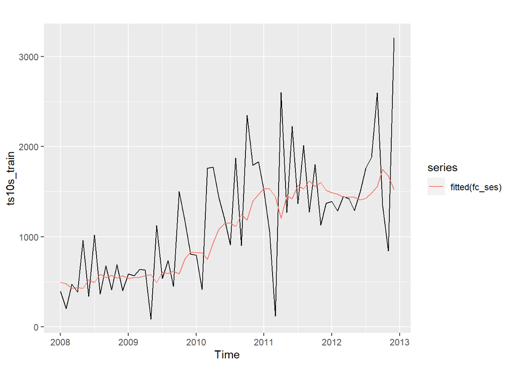

```r
autoplot(ts10s_train) + autolayer(fitted(fc_ses))
```

The following figures show the forecast and residual plot of the SES model:

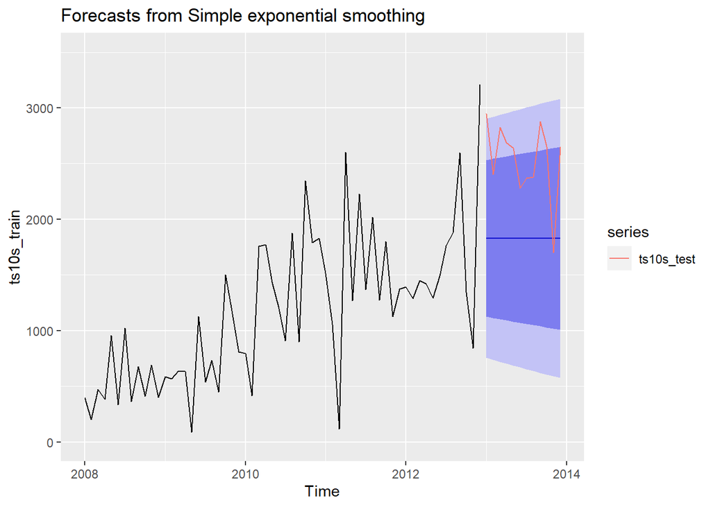

```r
autoplot(fc_ses, ylim=c(0, 3500))  + autolayer(ts10s_test)
```

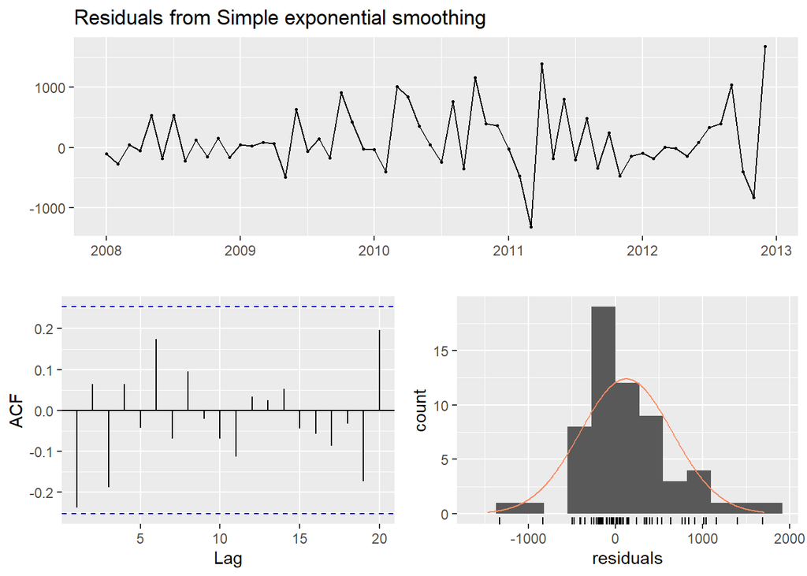

```
##
##  Ljung-Box test
##
## data:  Residuals from Simple exponential smoothing
## Q* = 11.072, df = 10, p-value = 0.3519
##
## Model df: 2.   Total lags used: 12
```

```r
checkresiduals(fc_ses)
```

Performance of the SES model:

```r
fc_ses_rmse <- rmse(as.numeric(fc_ses$mean), ts10s_actual)
fc_ses_mase <- mase(as.numeric(fc_ses$mean), ts10s_actual)

tscv_ses <- tsCV(ts10s_train, ses, h = 12)
tscv_ses_rmse <- rmse_e(as.numeric(tscv_ses))
message("SES model: MASE=", fc_ses_mase, " RMSE=", fc_ses_rmse, " RMSE(tsCV)=", tscv_ses_rmse)
```

```
## SES model: MASE=1.89 RMSE=777.03 RMSE(tsCV)=615.2
```

### 4.2 Exponential Smoothing with Trend: Holt’s Linear Trend Model

**4.2.1 Definition**
Recall that in SES,
$$\hat{y_{t+h|t}}=l_{t}$$
$$l_{t}=\alpha y_{t}+(1-\alpha)l_{t-1}$$
Holt’s Linear Trend model added a trend component to the SES model:
$$\hat{y_{t+h|t}}=l_{t}+hb_{t}$$
where,
$$b_{t}=\beta^{*}(l_{t}-l_{t-1})+(1-\beta^{*})b_{t-1},\text{ where }0\leq \beta^{*}\leq1$$

**4.2.2 Parameter Selection**  
The parameters, $\alpha$, $\beta^{*}$, $l_{0}$ and $b_{0}$ can be chosen by minimizing the squared error.

**4.2.3 Example: Monthly Sales Data of an Item**  
I will use the same item with ID 10 as an example.  
Fit a Holt’s Linear Trend model to the training data yields the following results:

```r
fc_holtl <- holt(ts10s_train, h = 12, damped=F)

summary(fc_holtl)
```

```
##
## Forecast method: Holt's method
##
## Model Information:
## Holt's method
##
## Call:
##  holt(y = ts10s_train, h = 12, damped = F)
##
##   Smoothing parameters:
##     alpha = 1e-04
##     beta  = 1e-04
##
##   Initial states:
##     l = 381.0541
##     b = 25.8836
##
##   sigma:  511.9376
##
##      AIC     AICc      BIC
## 1000.105 1001.217 1010.577
##
## Error measures:
##                     ME     RMSE      MAE       MPE     MAPE      MASE
## Training set -4.331786 494.5787 386.0344 -45.05156 65.93015 0.6195343
##                    ACF1
## Training set -0.1581153
##
## Forecasts:
##          Point Forecast    Lo 80    Hi 80     Lo 95    Hi 95
## Jan 2013       1958.604 1302.530 2614.679  955.2253 2961.984
## Feb 2013       1984.462 1328.388 2640.536  981.0829 2987.841
## Mar 2013       2010.320 1354.245 2666.394 1006.9405 3013.699
## Apr 2013       2036.177 1380.103 2692.252 1032.7980 3039.557
## May 2013       2062.035 1405.960 2718.109 1058.6555 3065.414
## Jun 2013       2087.893 1431.818 2743.967 1084.5129 3091.272
## Jul 2013       2113.750 1457.675 2769.825 1110.3703 3117.130
## Aug 2013       2139.608 1483.533 2795.683 1136.2276 3142.988
## Sep 2013       2165.465 1509.390 2821.541 1162.0848 3168.846
## Oct 2013       2191.323 1535.247 2847.399 1187.9419 3194.704
## Nov 2013       2217.181 1561.105 2873.257 1213.7989 3220.562
## Dec 2013       2243.038 1586.962 2899.115 1239.6558 3246.421
```

Note that the parameters, $\alpha$, $\beta^{*}$, $l_{0}$ and $b_{0}$ are estimated and listed in the summary.

The following figures show the forecast and residual plot of the Holt’s Linear Trend model:

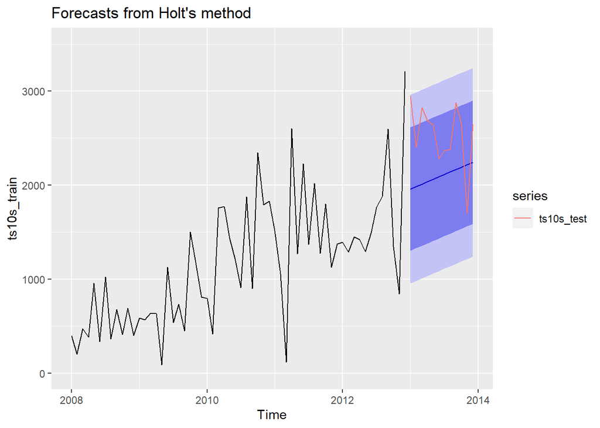

```r
autoplot(fc_holtl, ylim=c(0, 3500))  + autolayer(ts10s_test)
```

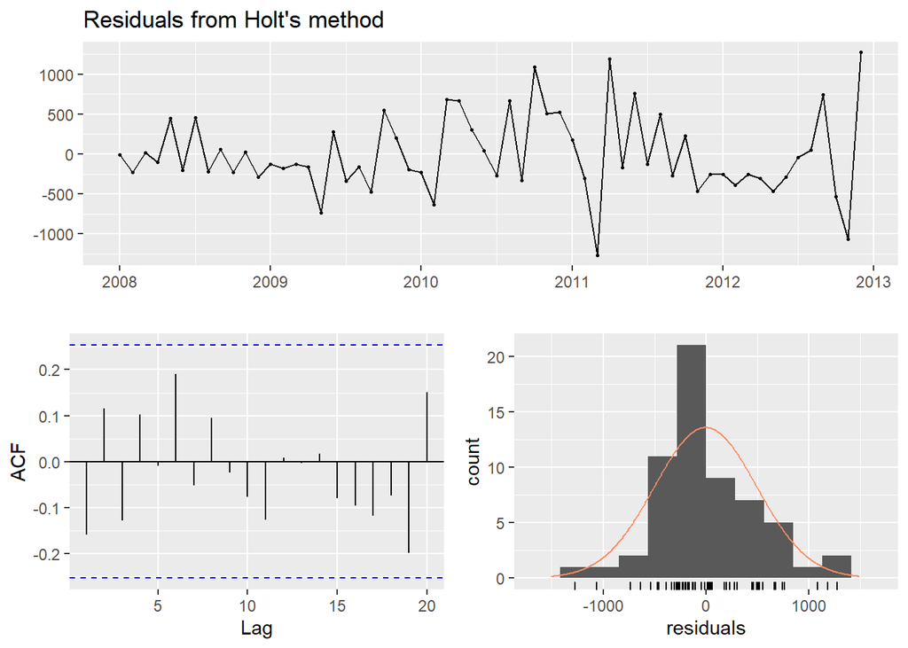

```
##
##  Ljung-Box test
##
## data:  Residuals from Holt's method
## Q* = 9.253, df = 8, p-value = 0.3214
##
## Model df: 4.   Total lags used: 12
```

```r
checkresiduals(fc_holtl)
```

Performance of Holt’s Linear Trend model:

```r
fc_holtl_rmse <- rmse(as.numeric(fc_holtl$mean), ts10s_actual)
fc_holtl_mase <- mase(as.numeric(fc_holtl$mean), ts10s_actual)

tscv_holtl <- tsCV(ts10s_train, holt, h = 12, damped=F)
tscv_holtl_rmse <- rmse_e(as.numeric(tscv_holtl))
message("Holt's Linear Trend model: MASE=", fc_holtl_mase, " RMSE=", fc_holtl_rmse, " RMSE(tsCV)=", tscv_holtl_rmse)
```

```
## Holt's Linear Trend model: MASE=1.35 RMSE=569.64 RMSE(tsCV)=799.5
```

### 4.3 Damped Holt’s Trend Model

**4.3.1 Definition**
Holt’s Trend model is generalized by adding a damping parameter $\phi$ to the trend component:
$$\hat{y_{t+h|t}}=l_{t}+(\phi+\phi^{2}+...+\phi^{h})b_{t},\text{ where }0\leq\phi\leq 1$$
$$l_{t}=\alpha y_{t}+(1-\alpha)(l_{t-1}+\phi b_{t-1}$$
$$b_{t}=\beta^{*}(l_{t}-l_{t-1})+(1-\beta^{*})\phi b_{t-1}$$
If $\phi=1$, it is identical to Holt’s Linear Trend model;
If $\phi=0$, it is identical to SES model.

**4.3.2 Parameter Selection**  
The parameters, $\alpha$, $\beta^{*}$, $l_{0}$, $b_{0}$ and $\phi$ can be chosen by minimizing the squared error.

**4.3.3 Example: Monthly Sales Data of an Item**  
I will use the same item with ID 10 as an example.  
Fit a Holt’s Trend model to the training data yields the following results:

```r
fc_holt <- holt(ts10s_train, h = 12, damped=T)

summary(fc_holt)
```

```
##
## Forecast method: Damped Holt's method
##
## Model Information:
## Damped Holt's method
##
## Call:
##  holt(y = ts10s_train, h = 12, damped = T)
##
##   Smoothing parameters:
##     alpha = 0.0746
##     beta  = 0.0027
##     phi   = 0.98
##
##   Initial states:
##     l = 381.1223
##     b = 25.7031
##
##   sigma:  540.9118
##
##      AIC     AICc      BIC
## 1007.631 1009.216 1020.197
##
## Error measures:
##                    ME     RMSE      MAE       MPE     MAPE      MASE       ACF1
## Training set 70.44825 517.8836 383.8213 -36.13761 61.47332 0.6159826 -0.1703087
##
## Forecasts:
##          Point Forecast    Lo 80    Hi 80    Lo 95    Hi 95
## Jan 2013       1797.406 1104.200 2490.613 737.2386 2857.574
## Feb 2013       1811.673 1116.404 2506.941 748.3508 2874.994
## Mar 2013       1825.653 1128.189 2523.117 758.9743 2892.333
## Apr 2013       1839.355 1139.562 2539.148 769.1140 2909.596
## May 2013       1852.782 1150.527 2555.037 778.7755 2926.789
## Jun 2013       1865.941 1161.090 2570.792 787.9645 2943.917
## Jul 2013       1878.836 1171.257 2586.416 796.6870 2960.986
## Aug 2013       1891.474 1181.034 2601.915 804.9493 2977.999
## Sep 2013       1903.859 1190.426 2617.292 812.7579 2994.960
## Oct 2013       1915.996 1199.441 2632.551 820.1196 3011.873
## Nov 2013       1927.891 1208.084 2647.697 827.0414 3028.740
## Dec 2013       1939.547 1216.362 2662.733 833.5303 3045.564
```

Note that the parameters, $\alpha$, $\beta^{*}$, $l_{0}$, $b_{0}$ and $\phi$ are estimated and listed in the summary.

The following figures show the forecast and residual plot of the Holt’s Trend model:

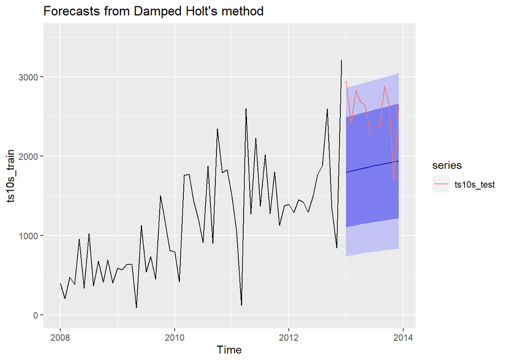

```r
autoplot(fc_holt, ylim=c(0, 3500))  + autolayer(ts10s_test)
```

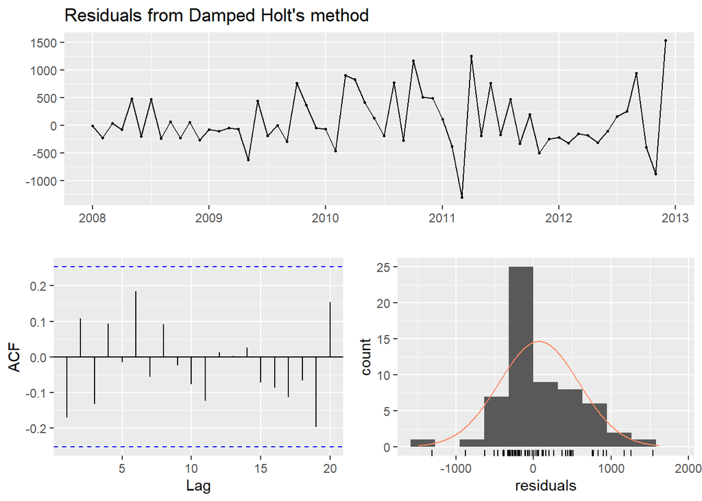

```
##
##  Ljung-Box test
##
## data:  Residuals from Damped Holt's method
## Q* = 9.1526, df = 7, p-value = 0.2419
##
## Model df: 5.   Total lags used: 12
```

```r
checkresiduals(fc_holt)
```

Performance of Holt’s Trend model:

```r
fc_holt_rmse <- rmse(as.numeric(fc_holt$mean), ts10s_actual)
fc_holt_mase <- mase(as.numeric(fc_holt$mean), ts10s_actual)

tscv_holt <- tsCV(ts10s_train, holt, h = 12, damped=T)
tscv_holt_rmse <- rmse_e(as.numeric(tscv_holt))
message("Holt's Trend model: MASE=", fc_holt_mase, " RMSE=", fc_holt_rmse, " RMSE(tsCV)=", tscv_holt_rmse)
```

```
## Holt's Trend model: MASE=1.82 RMSE=748.04 RMSE(tsCV)=816.35
```

### 4.4 Exponential Smoothing with Trend and Seasonality: Holt-Winters Model

**4.4.1 Definition**
Denote the Holt’s Trend model as $\hat{H_{t+h|t}}$, recall that
$$\hat{H_{t+h|t}}=l_{t}+(\phi+\phi^{2}+...+\phi^{h})b_{t},\text{ where }0\leq\phi\leq 1$$
Holt-Winters model added a seasonal component $s_{t-m+h_m^+}$. There are two variations:

1. Additive Model
   $$\hat{y_{t+h|t}}=\hat{H_{t+h|t}}+s_{t-m+h_m^+}$$
   $$l_t=\alpha(y_t-s_{t-m})+(1-\alpha)(l_{t-1}+\phi b_{t-1})$$
   $$b_t= \beta^*(l_t-l_{t-1})+(1-\beta^*)\phi b_{t-1}$$
   $$s_t=\gamma(y_t-l_{t-1}-b_{t-1})+(1-\gamma)s_{t-m}$$
2. Multiplicative Model
   $$\hat{y_{t+h|t}}=\hat{H_{t+h|t}}\cdot s_{t-m+h_m^+}$$
   $$l_t=\frac{\alpha y_t}{s_{t-m}}+(1-\alpha)(l_{t-1}+\phi b_{t-1})$$
   $$b_t= \beta^*(l_t-l_{t-1})+(1-\beta^*)\phi b_{t-1}$$
   $$s_t=\frac{\gamma y_t}{l_{t-1}-b_{t-1}}+(1-\gamma)s_{t-m}$$
   where,
   $$m=\text{period of seasonality}$$
   $$0\leq\gamma\leq 1-\alpha$$

Note that, seasonal component averages zero from the additive model, and one for the multiplicative model.  
In general, multiplication method is used when seasonal variation increases with the level of the series.

**4.4.2 Example: Monthly Sales Data of an Item**  
I will use the same item with ID 10 as an example.  
Fit a Holt-Winters model (additive) to the training data yields the following results:

```r
fc_hwa <- hw(ts10s_train, seasonal = "additive", h = 12, damped=T)
summary(fc_hwa)
```

```
##
## Forecast method: Damped Holt-Winters' additive method
##
## Model Information:
## Damped Holt-Winters' additive method
##
## Call:
##  hw(y = ts10s_train, h = 12, seasonal = "additive", damped = T)
##
##   Smoothing parameters:
##     alpha = 0.0086
##     beta  = 1e-04
##     gamma = 1e-04
##     phi   = 0.9776
##
##   Initial states:
##     l = 436.3935
##     b = 40.931
##     s = -13.7389 78.0572 409.9514 -259.8315 184.8656 -82.0475
##            224.9423 -234.4989 363.3299 -222.9805 -347.1133 -100.9357
##
##   sigma:  577.169
##
##      AIC     AICc      BIC
## 1024.648 1041.331 1062.346
##
## Error measures:
##                     ME     RMSE      MAE     MPE     MAPE      MASE      ACF1
## Training set -59.17676 488.6092 369.8912 -48.791 66.97524 0.5936267 -0.166757
##
## Forecasts:
##          Point Forecast     Lo 80    Hi 80     Lo 95    Hi 95
## Jan 2013       1630.583  890.9107 2370.254  499.3521 2761.813
## Feb 2013       1394.351  654.6512 2134.051  263.0776 2525.625
## Mar 2013       1528.229  788.5004 2267.958  396.9115 2659.547
## Apr 2013       2123.983 1384.2241 2863.741  992.6196 3255.345
## May 2013       1535.561  795.7730 2275.350  404.1526 2666.970
## Jun 2013       2003.984 1264.1647 2743.803  872.5281 3135.440
## Jul 2013       1705.944  966.0933 2445.794  574.4401 2837.447
## Aug 2013       1981.526 1241.6436 2721.408  849.9736 3113.078
## Sep 2013       1545.434  805.5196 2285.349  413.8324 2677.036
## Oct 2013       2223.323 1483.3753 2963.271 1091.6707 3354.975
## Nov 2013       1899.523 1159.5418 2639.504  767.8194 3031.227
## Dec 2013       1815.896 1075.8803 2555.911  684.1399 2947.651
```

Fit a Holt-Winters model (multiplicative) to the training data yields the following results:

```r
fc_hwm <- hw(ts10s_train, seasonal = "multiplicative", h = 12, damped=T)
summary(fc_hwm)
```

```
##
## Forecast method: Damped Holt-Winters' multiplicative method
##
## Model Information:
## Damped Holt-Winters' multiplicative method
##
## Call:
##  hw(y = ts10s_train, h = 12, seasonal = "multiplicative", damped = T)
##
##   Smoothing parameters:
##     alpha = 0.0186
##     beta  = 1e-04
##     gamma = 5e-04
##     phi   = 0.978
##
##   Initial states:
##     l = 444.3509
##     b = 40.9945
##     s = 1.1391 0.956 1.1465 0.9431 1.1801 1.003
##            1.2071 0.8456 1.0979 0.8365 0.669 0.976
##
##   sigma:  0.4661
##
##      AIC     AICc      BIC
## 1014.354 1031.037 1052.052
##
## Error measures:
##                     ME     RMSE      MAE      MPE     MAPE      MASE       ACF1
## Training set -53.01317 465.7335 369.7757 -50.0199 66.90604 0.5934412 -0.1267978
##
## Forecasts:
##          Point Forecast    Lo 80    Hi 80    Lo 95    Hi 95
## Jan 2013       1686.300 678.9854 2693.615 145.7450 3226.856
## Feb 2013       1163.064 468.1590 1857.968 100.2987 2225.828
## Mar 2013       1463.162 588.7714 2337.552 125.8972 2800.426
## Apr 2013       1931.405 776.9487 3085.862 165.8163 3696.994
## May 2013       1496.190 601.6864 2390.694 128.1648 2864.216
## Jun 2013       2146.149 862.7952 3429.503 183.4287 4108.869
## Jul 2013       1793.140 720.6531 2865.626 152.9131 3433.366
## Aug 2013       2120.344 851.8882 3388.799 180.4085 4060.279
## Sep 2013       1703.256 684.1012 2722.411 144.5931 3261.919
## Oct 2013       2080.903 835.5182 3326.287 176.2515 3985.554
## Nov 2013       1743.132 699.6775 2786.586 147.3062 3338.957
## Dec 2013       2086.459 837.2226 3335.696 175.9166 3997.002
```

Figure below plots the forecast of additive model; and the multiplicative model is shown as the red line.

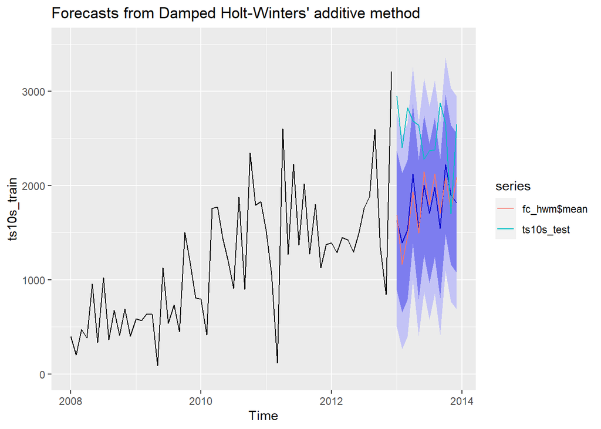

```r
autoplot(fc_hwa, ylim=c(0, 3500)) + autolayer(fc_hwm$mean) + autolayer(ts10s_test)
```

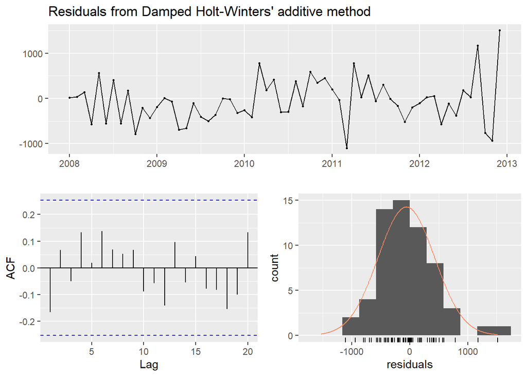

```
##
##  Ljung-Box test
##
## data:  Residuals from Damped Holt-Winters' additive method
## Q* = 14.886, df = 3, p-value = 0.001916
##
## Model df: 17.   Total lags used: 20
```

```r
checkresiduals(fc_hwa)
```

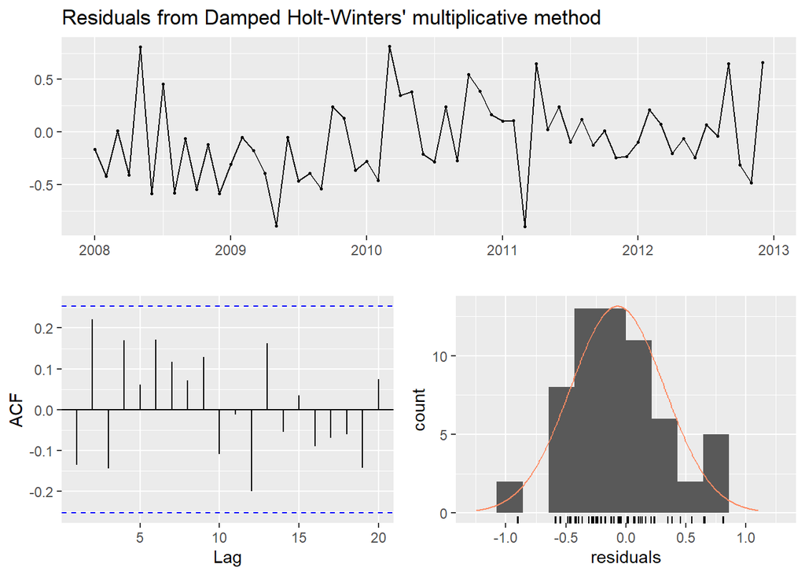

```
##
##  Ljung-Box test
##
## data:  Residuals from Damped Holt-Winters' multiplicative method
## Q* = 22.623, df = 3, p-value = 4.839e-05
##
## Model df: 17.   Total lags used: 20
```

```r
checkresiduals(fc_hwm)
```

Performance of Holt-Winters model:

```r
fc_hwa_rmse <- rmse(as.numeric(fc_hwa$mean), ts10s_actual)
fc_hwa_mase <- mase(as.numeric(fc_hwa$mean), ts10s_actual)

tscv_hwa <- tsCV(ts10s_train, hw, seasonal = "additive", h = 12, damped=T)
tscv_hwa_rmse <- rmse_e(as.numeric(tscv_hwa))
message("Holt-Winters Additive model: MASE=", fc_hwa_mase, " RMSE=", fc_hwa_rmse, " RMSE(tsCV)=", tscv_hwa_rmse)
```

```
## Holt-Winters Additive model: MASE=2.04 RMSE=882.59 RMSE(tsCV)=724.44
```

```r
fc_hwm_rmse <- rmse(as.numeric(fc_hwm$mean), ts10s_actual)
fc_hwm_mase <- mase(as.numeric(fc_hwm$mean), ts10s_actual)

tscv_hwm <- tsCV(ts10s_train, hw, seasonal = "multiplicative", h = 12, damped=T)
tscv_hwm_rmse <- rmse_e(as.numeric(tscv_hwm))
message("Holt-Winters Multiplicative model: MASE=", fc_hwm_mase, " RMSE=", fc_hwm_rmse, " RMSE(tsCV)=", tscv_hwm_rmse)
```

```
## Holt-Winters Multiplicative model: MASE=1.97 RMSE=881.06 RMSE(tsCV)=778.59
```

### 4.5 State Space Models for Exponential Smoothing

Sections above have introduced types of trend component and seasonal component of exponential smoothing models. The combinations of these types result in a set of states. Moreover, the errors can be further classified into additive and multiplicative. As a result, the taxonomy of the state space is denoted by (Error, Trend, Seasonal) format, namely **ETS model**. The common values of ETS components includes:

- Error (E) = {A: additive, M: multiplicative}
- Trend (T) = {N: none, A: additive, Ad: additive damped}
- Seasonal (S) = {N: none, A: additive, M: multiplicative}

The ETS model targets to choose the best model from the state space by minimizing the corrected Akaike’s Information Criterion (AICC).

**4.5.1 Example: Monthly Sales Data of an Item**  
I will use the same item with ID 10 as an example.  
Fit an ETS model to the training data yields the following results:

```r
m_ets <- ets(ts10s_train)
fc_ets <- forecast(m_ets, h=12)
summary(m_ets)
```

```
## ETS(M,A,N)
##
## Call:
##  ets(y = ts10s_train)
##
##   Smoothing parameters:
##     alpha = 1e-04
##     beta  = 1e-04
##
##   Initial states:
##     l = 386.1763
##     b = 25.4713
##
##   sigma:  0.4338
##
##      AIC     AICc      BIC
## 988.1923 989.3034 998.6640
##
## Training set error measures:
##                   ME     RMSE      MAE       MPE    MAPE      MASE       ACF1
## Training set 3.03497 494.7032 384.5623 -44.41629 65.5654 0.6171718 -0.1585509
```

The selected model is a Holt’s Linear Trend model with multiplication error.

The following figures show the forecast and residual plot of the ETS model:

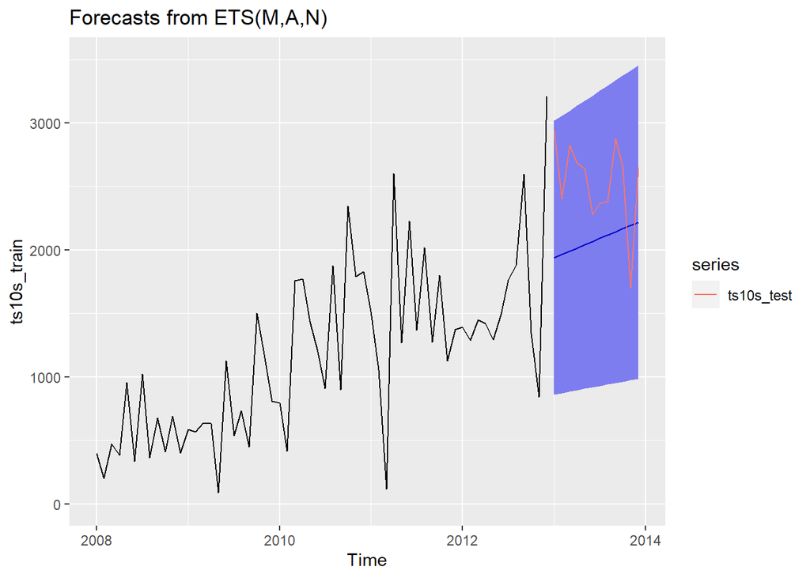

```r
autoplot(fc_ets, ylim=c(0, 3500))  + autolayer(ts10s_test)
```

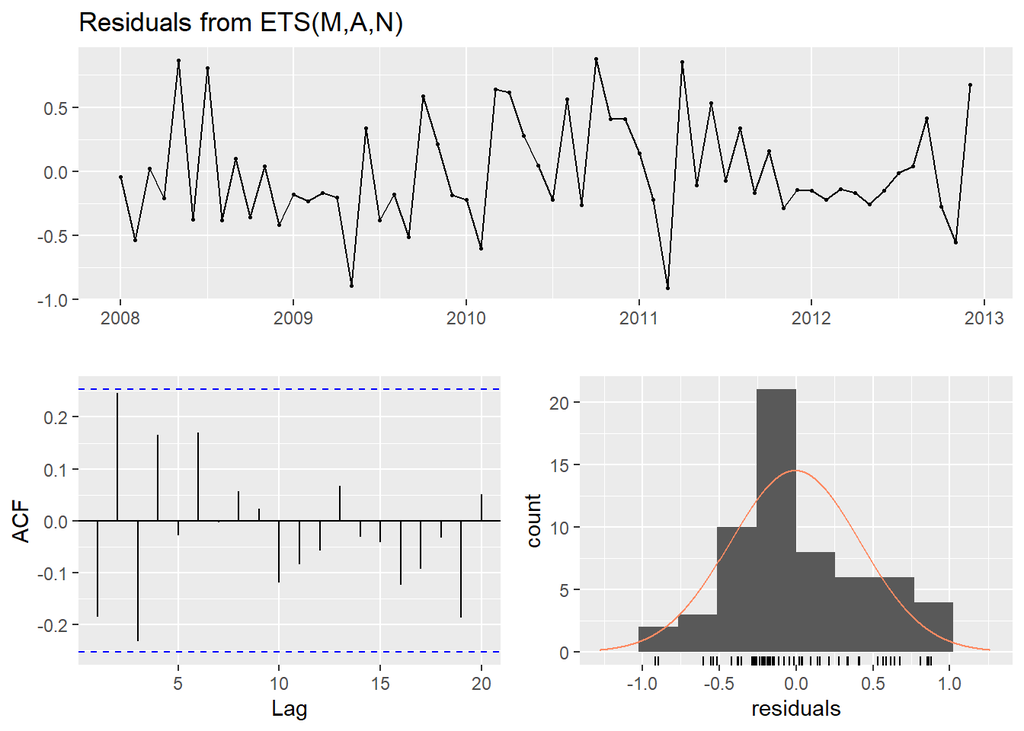

```
##
##  Ljung-Box test
##
## data:  Residuals from ETS(M,A,N)
## Q* = 15.56, df = 8, p-value = 0.04913
##
## Model df: 4.   Total lags used: 12
```

```r
checkresiduals(fc_ets)
```

Performance of ETS model:

```r
fc_ets_rmse <- rmse(as.numeric(fc_ets$mean), ts10s_actual)
fc_ets_mase <- mase(as.numeric(fc_ets$mean), ts10s_actual)

tscv_ets <- tsCV(ts10s_train, function(x,h) forecast(ets(x),h=h), h = 12)
tscv_ets_rmse <- rmse_e(as.numeric(tscv_ets))
message("ETS model: MASE=", fc_ets_mase, " RMSE=", fc_ets_rmse, " RMSE(tsCV)=", tscv_ets_rmse)
```

```
## ETS model: MASE=1.4 RMSE=585.62 RMSE(tsCV)=583.6
```

### 4.6 Summary

Table below summarizes the performances of the basic models and the exponential smoothing models from the examples in the above sections:

```r
data.frame(Model=c("Naive","Mean","Seasonal Naive","SES","Holt's Linear Trend","Holt's Trend",
                   "Holt-Winters Additive","Holt-Winters Multiplicative","ETS"),
           `MASE(test)`=c(fc_naive_mase,fc_mean_mase,fc_snaive_mase,fc_ses_mase,fc_holtl_mase,fc_holt_mase,
                          fc_hwa_mase,fc_hwm_mase,fc_ets_mase),
           `RMSE(test)`=c(fc_naive_rmse,fc_mean_rmse,fc_snaive_rmse,fc_ses_rmse,fc_holtl_rmse,fc_holt_rmse,
                          fc_hwa_rmse,fc_hwm_rmse,fc_ets_rmse),
           `RMSE(tsCV)`=c(tscv_naive_rmse,tscv_mean_rmse,tscv_snaive_rmse,tscv_ses_rmse,tscv_holtl_rmse,tscv_holt_rmse,
                          tscv_hwa_rmse,tscv_hwm_rmse,tscv_ets_rmse)) %>%
  knitr::kable()
```

| Model | MASE.test. | RMSE.test. | RMSE.tsCV. |
| --- | --- | --- | --- |
| Naive | 1.75 | 748.61 | 713.74 |
| Mean | 3.56 | 1407.68 | 765.03 |
| Seasonal Naive | 2.50 | 1043.72 | 754.58 |
| SES | 1.89 | 777.03 | 615.20 |
| Holt’s Linear Trend | 1.35 | 569.64 | 799.50 |
| Holt’s Trend | 1.82 | 748.04 | 816.35 |
| Holt-Winters Additive | 2.04 | 882.59 | 724.44 |
| Holt-Winters Multiplicative | 1.97 | 881.06 | 778.59 |
| ETS | 1.40 | 585.62 | 583.60 |